# Preliminary Results

JW

2024-09-13

# Updates

- Log Transformation of load for the peak load ARX Model

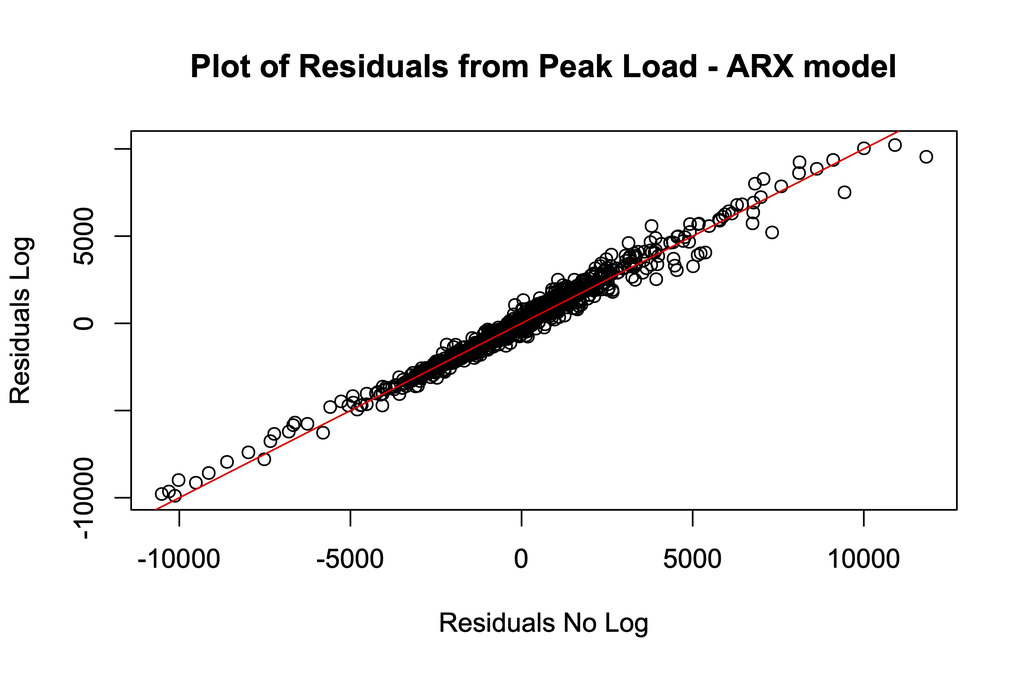

- Shaake Shuffle (Grothe et al. 2023), Seite 10, $\sigma_{t,h} = 1$ im “raw-error” case - Warum?

# Problem Statement

Predicting the energy peak demand for the next 24 hours!

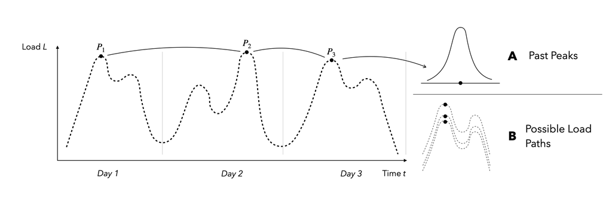

We consider the data structure a *(DSA)* and the data structure B *(DSB)*

# Models

$P_d = \hat{P_d} + \epsilon_d \Leftrightarrow F_{P_d}^{-1}(q) = \hat{P_d} + F_{\epsilon_t}^{-1}(q)$

## Point Based Models

One year for training the model and 182 days to learn the error distribution.

1. ARIMA (pb_arima) - *DSA*
   - Input: ARIMA(1,1,1), isHoliday, Weekday
   - Output: 1 peak for the next day
2. AR7 (pb_ar7) - *DSA*
   - Input: Lag PeakLoad(1-7), isHoliday, Weekday
   - Output: 1 peak for the next day
3. Random Forest (pb_rf) - *DSA*
   - Input: Lag PeakLoad (1-21), Yearly Componont (Fourier), HourInt, Weekday
   - Output: 1 peak for the next day

## Distribution Based Models

1. Historical Simulation (db_hist_sim) - *DSA, DSB*
   - Input: 90 past peaks
   - Output: Peak dis (90 elements)
2. Quantile Regression Averaging (db_qra) - *DSA*
   - Input: 3 peak point forecasts (Training length is 182)
   - Output: Peak dis (90 elements)
3. Load Path Simulation - AR1 (db_ar1) - *DSB*
   - Input: Stationary Load Series (with factors: Yearly Component(Fourier), Weekday, Hour, Weekday * Hour, isHoliday)
   - Output: 90 Load Paths (24 hour) for next day
4. Shaake Shuffle (db_ss_ar7, db_ss_arima, db_ss_rf) - *DSB*
   - Input: All point based model, but one for every hour -> 24 Models
   - Output: 90 Load Paths (24 hour) for next day

# Results

$n = 614$

CRPS Means

| db_ar1 | db_hist_sim | db_qra | db_ss_ar7 | db_ss_arima | db_ss_rf | pb_ar7 | pb_arima | pb_rf |
| --- | --- | --- | --- | --- | --- | --- | --- | --- |
| 1418.681 | 4072.811 | 1241.914 | 1250.438 | 1177.006 | 1280.902 | 1329.032 | 1288.464 | 1411.794 |

**Ranking:**

1. db_ss_arima
2. db_qra
3. db_ss_ar7
4. db_ss_rf
5. pb_arima
6. pb_ar7
7. pb_rf
8. db_ar1
9. db_hist_sim

## CRPS Plots

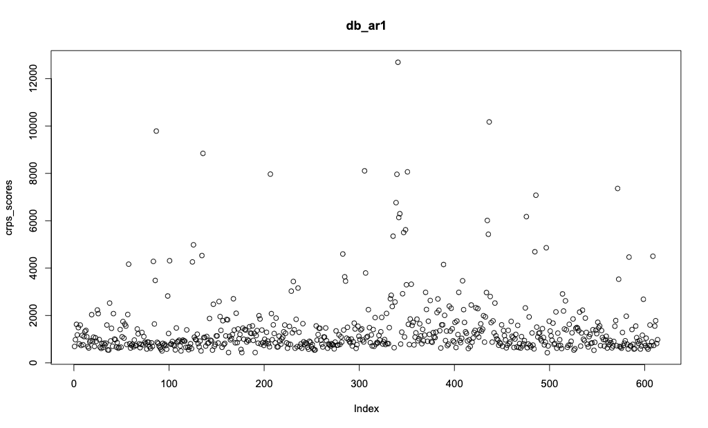

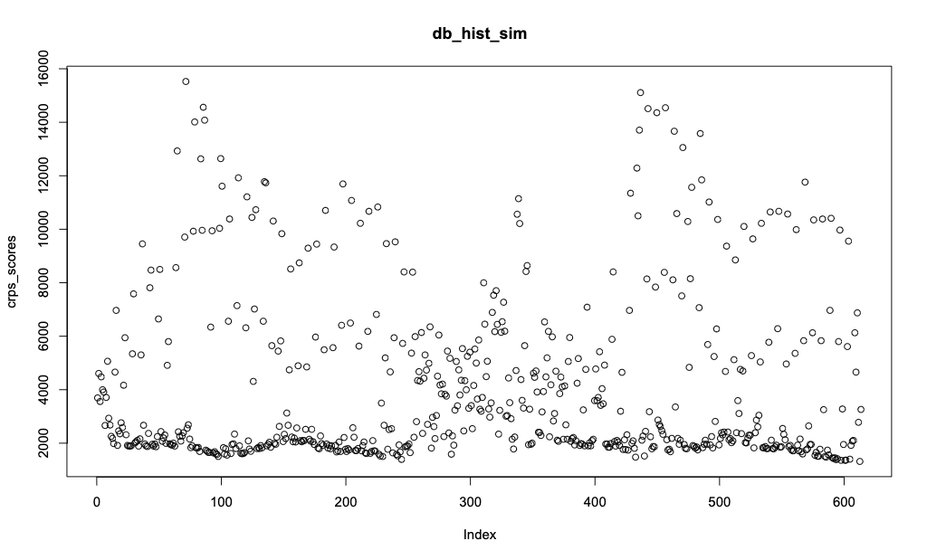

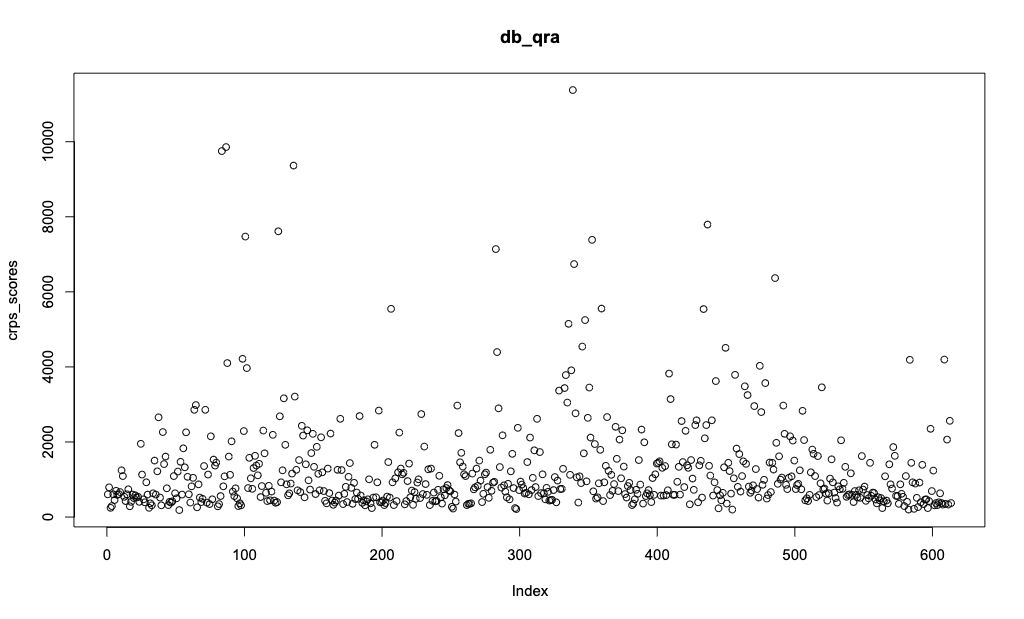

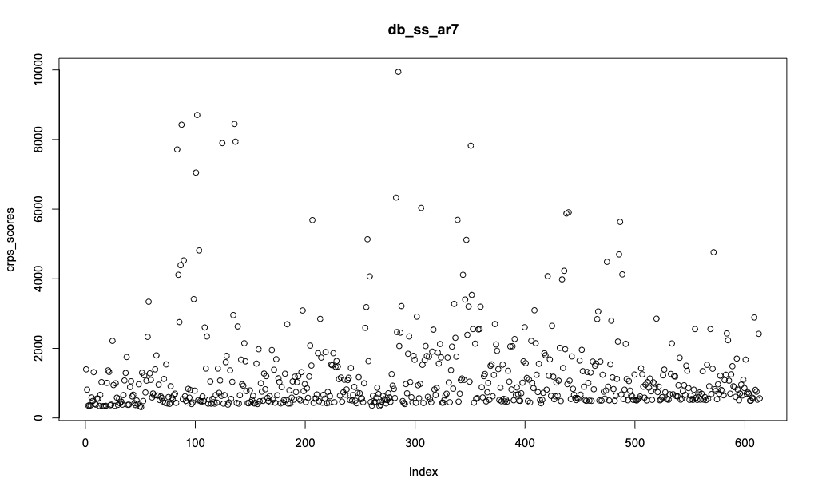

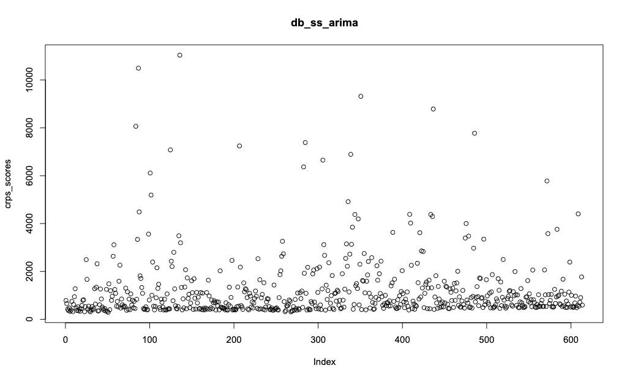

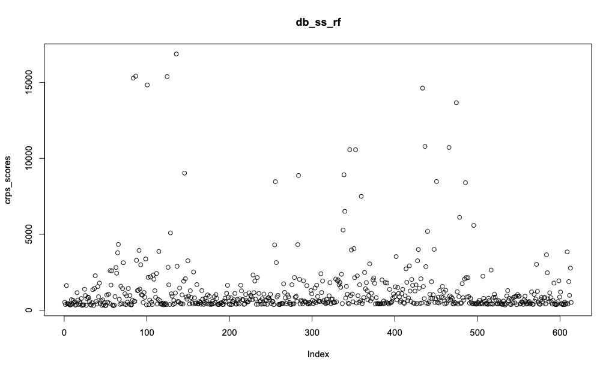

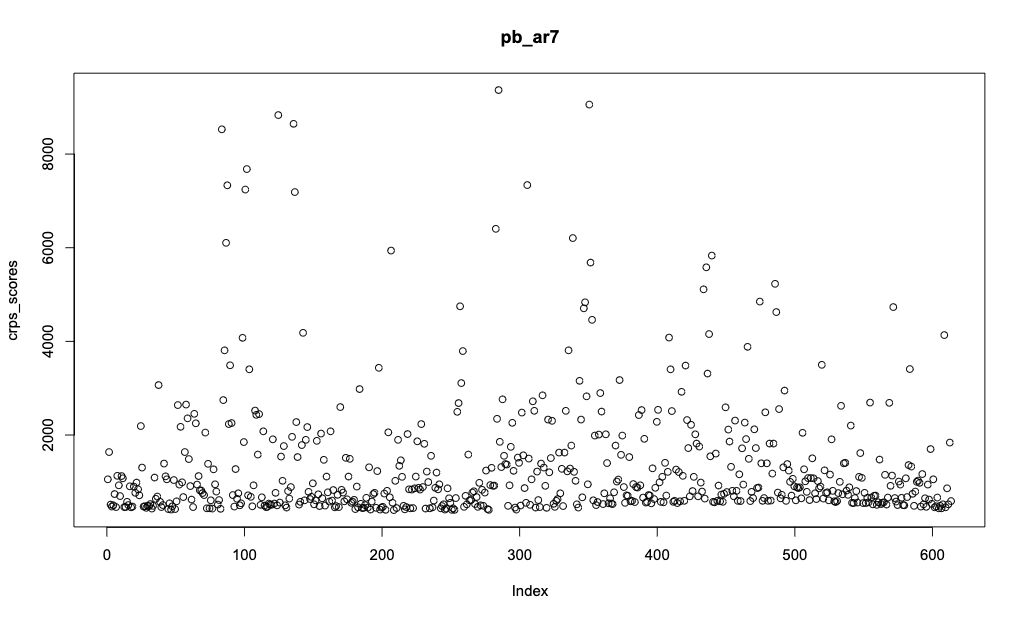

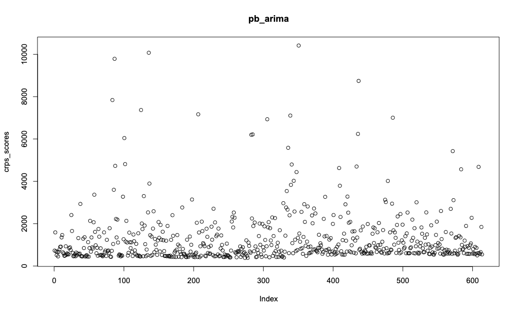

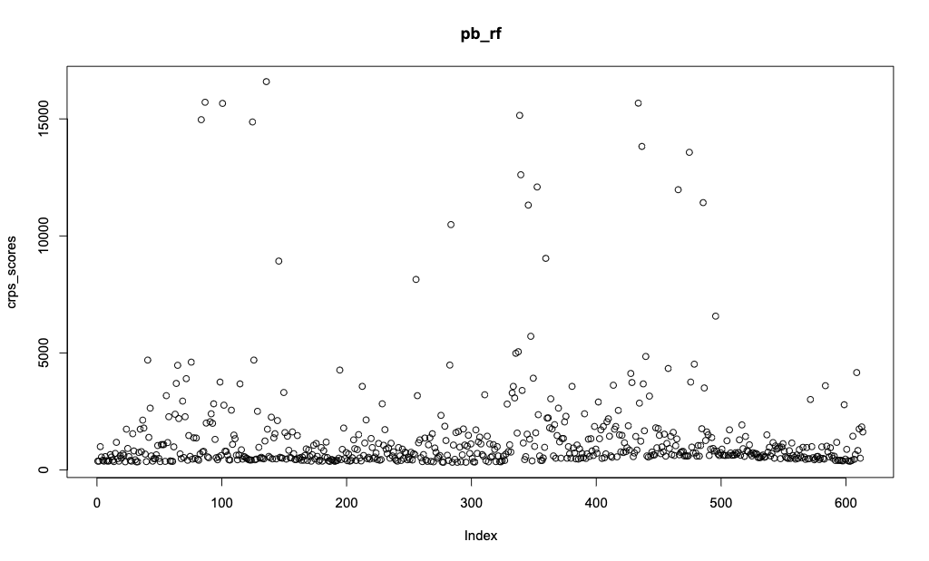

## Variance of Peak Distribution

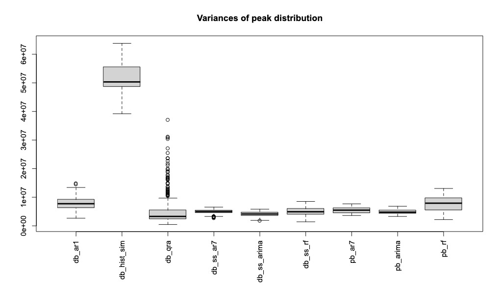

## PIT

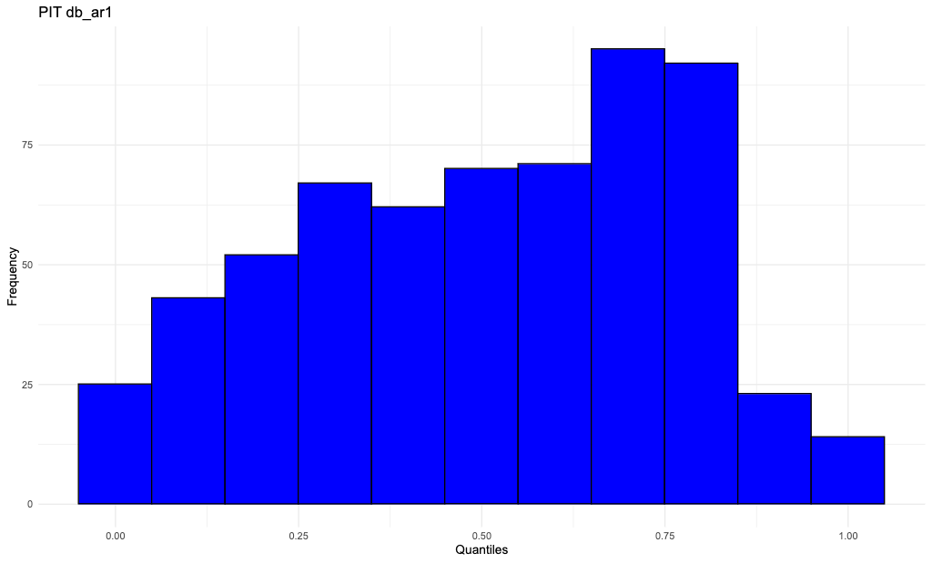

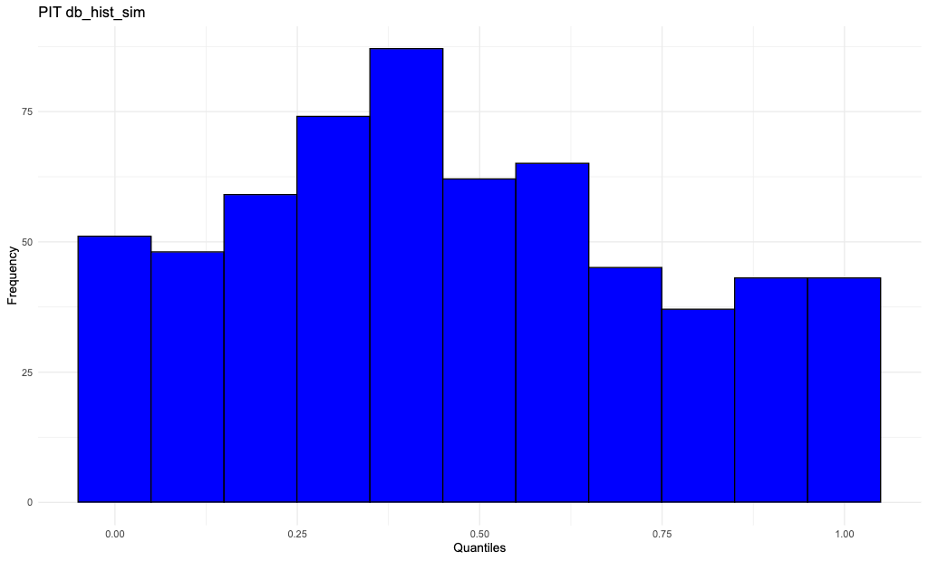

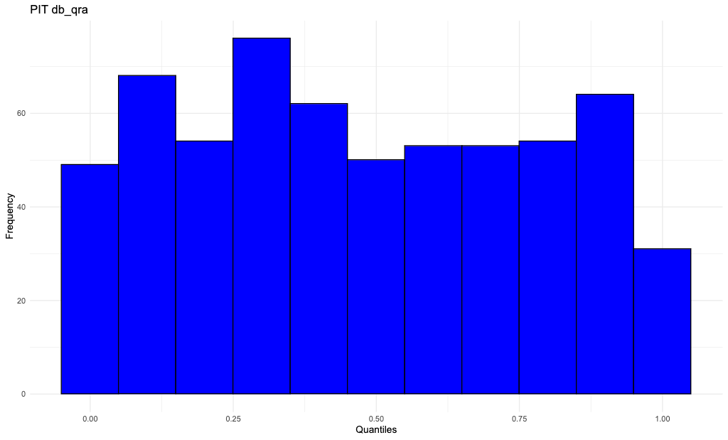

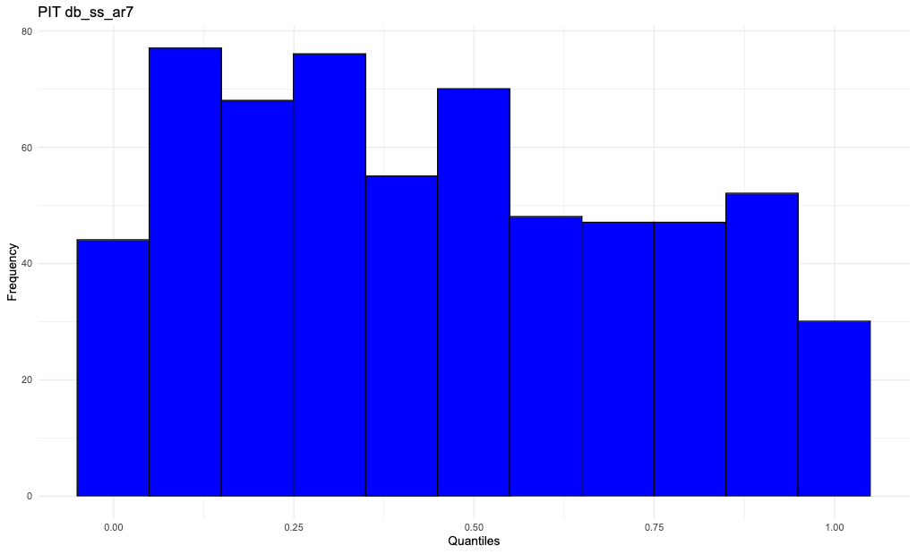

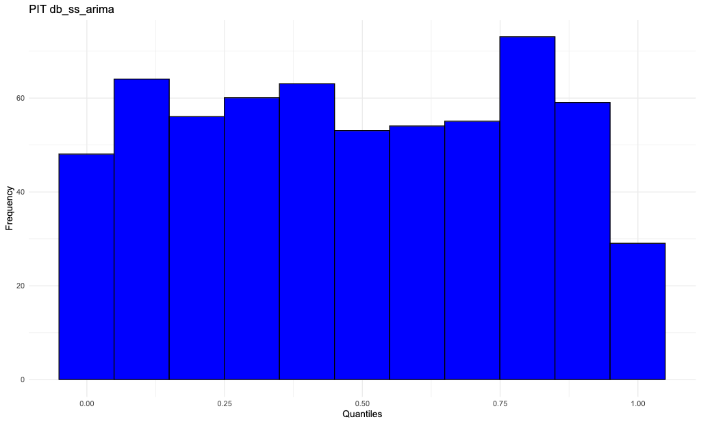

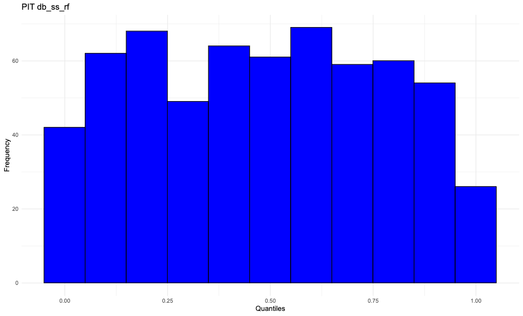

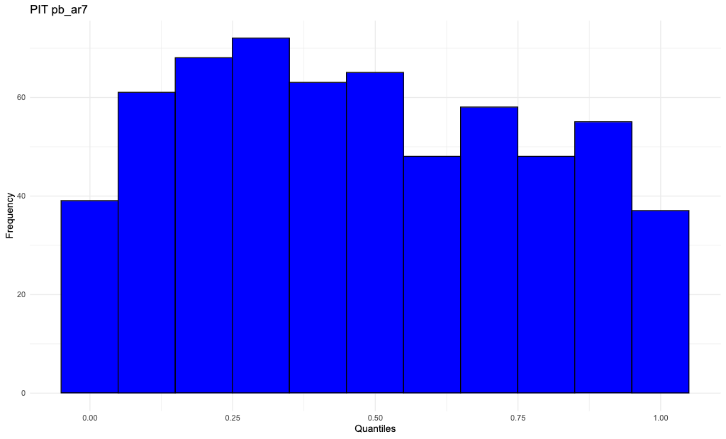

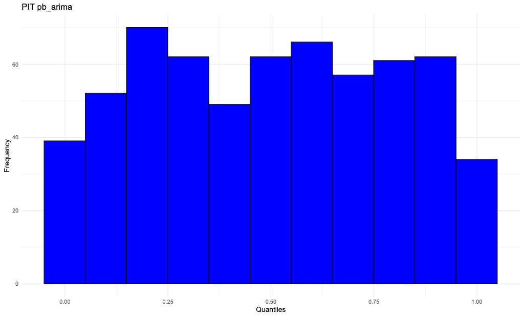

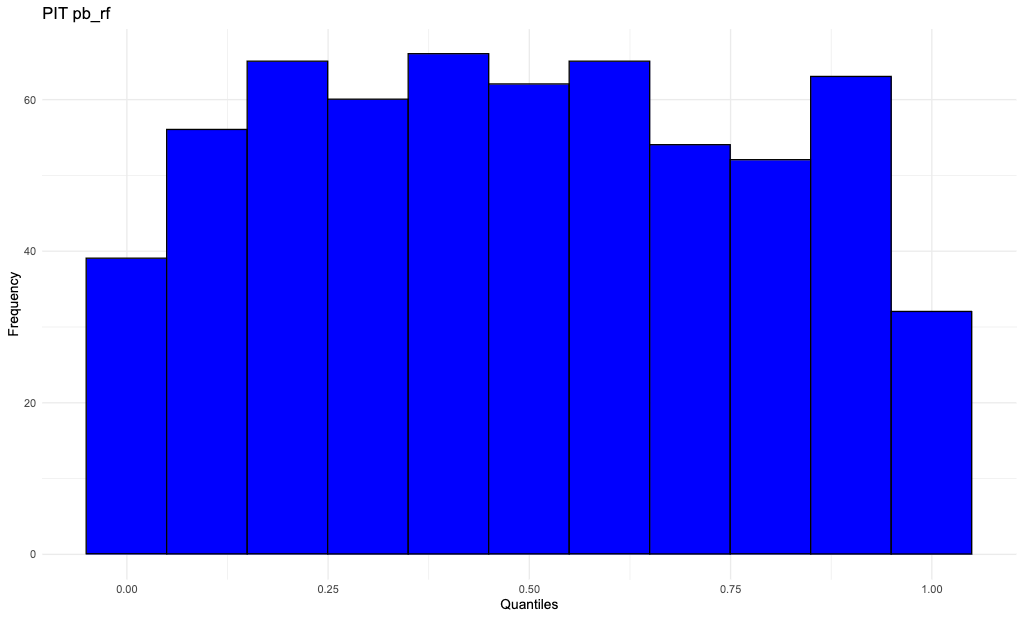

## UC

Unconditional Coverage for several nominal coverages (NC)

| NC | db_ar1 | db_hist_sim | db_qra | db_ss_ar7 | db_ss_arima | db_ss_rf | pb_ar7 | pb_arima | pb_rf |
| --- | --- | --- | --- | --- | --- | --- | --- | --- | --- |
| 0.10 | 0.0765472 | 0.1335505 | 0.1482085 | 0.1482085 | 0.1319218 | 0.1270358 | 0.1172638 | 0.1188925 | 0.1074919 |
| 0.25 | 0.1954397 | 0.2573290 | 0.2785016 | 0.3078176 | 0.2736156 | 0.2801303 | 0.2736156 | 0.2622150 | 0.2605863 |
| 0.50 | 0.4657980 | 0.5716612 | 0.5456026 | 0.5798046 | 0.5195440 | 0.5276873 | 0.5553746 | 0.4983713 | 0.5179153 |
| 0.75 | 0.7899023 | 0.7996743 | 0.7573290 | 0.7899023 | 0.7377850 | 0.7719870 | 0.7719870 | 0.7442997 | 0.7605863 |
| 0.90 | 0.9723127 | 0.8973941 | 0.9022801 | 0.8941368 | 0.9153094 | 0.9055375 | 0.9039088 | 0.9022801 | 0.9022801 |